# Ventas Apple. Modelos ETS y ARIMA

Isabel Afán de Ribera

16 noviembre 2020

## Objetivo

El objetivo del presente trabajo es predecir las ventas de Apple mediante los datos trimestrales desde el 2T de 2008 hasta el 3T del 2017 obtenidos de Bloomerg. Para ello se aplicaran los modelos ETS y ARIMA relativos a series temporales y se decidirá cuál de ellos es el más adecuado para predecir las ventas.

## Descripción del dataset

El dataset relativo a las ventas de Apple consiste en 38 observaciones y 2 variables.

*`Trimestres`* `Ingresos`

```r
library(janitor) # Clean names
library(magrittr) # Pipe operators
library(skimr) # Beautiful Summarize
library(forecast) # series temporales
library(xts) # manejo datos de series temporales
library(ggplot2) # visualizacion
```

```r
raw_data <-  read.csv("IngresosApple.csv", sep = ";")
View(raw_data)
```

```r
raw_data %<>% clean_names()
colnames(raw_data)
```

```
## [1] "trimestre" "ingresos"
```

## Tratamiento de datos

```r
# datos de ventas
raw_ventas <- raw_data$ingresos
# convertimos los trimestres a formato fecha
raw_date <- seq(as.Date("2008/04/01"), as.Date("2017/07/01"), by = "quarter")
```

```r
# creamos un objeto XTS para pasar a serie temporal continua con libreria xts
x_Ventas <- xts(raw_ventas,order.by=raw_date)
```

```r
# pasamos las fechas a trimestres
x_Ventas <- to.quarterly(x_Ventas)
```

```r
# pasamos las ventas tambien a formato zoo con libreria forecast
z_Ventas <- as.zoo(x_Ventas$x_Ventas.Close)
```

```r
# cambio del nombre de la columna a Ventas
names(z_Ventas) = "Ventas"
```

## Análisis de la serie temporal

En primer lugar, graficamos las ventas de Apple para ver la tendencia seguida y su estacionalidad.

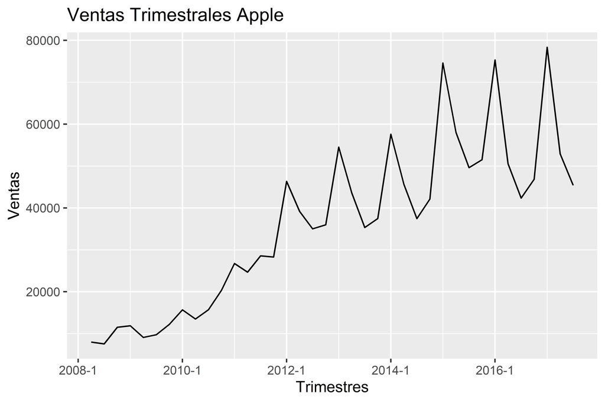

```r
# graficamos las ventas de Apple por trimestres
autoplot(z_Ventas) + ylab("Ventas") + ggtitle("Ventas Trimestrales Apple") + xlab("Trimestres")
```

Como puede observarse la serie es no estacionaria pues la media y la variabilidad cambian a lo largo del tiempo. Para convertirla en estacionaria vamos a aplicar los modelos ARIMA y ETS.

## Modelo ARIMA

```r
# excluimos los tres ultimos trimestres sorrespondientes al año 2017
cOmit <- 3

# seleccionamos las observaciones
nObs <- length(z_Ventas)

# submuestra para training
trVentas <- window(z_Ventas,start=index(z_Ventas[1]),end=index(z_Ventas[nObs-cOmit]))

# submuestra para testing
teVentas <- window(z_Ventas,start=index(z_Ventas[nObs-cOmit+1]),end=index(z_Ventas[nObs])
)
```

```r
# modelo ARIMA, lambda 0 para que aplique logaritmo
fit2 <- auto.arima(trVentas,lambda=0)
summary(fit2)
```

```
## Series: trVentas
## ARIMA(0,1,0)(0,1,0)[4]
## Box Cox transformation: lambda= 0
##
## sigma^2 estimated as 0.01472:  log likelihood=20.72
## AIC=-39.45   AICc=-39.3   BIC=-38.04
##
## Training set error measures:
##                     ME     RMSE      MAE       MPE     MAPE      MASE      ACF1
## Training set -764.5058 4786.405 3054.054 -1.321616 8.284962 0.4406634 0.1269135
```

```r
# AIC corregido de -39.3
# medidas de error dentro de la muestra, MAPE (error relativo) 8.284962  y RMSE 4786.405 (raíz del error cuadrático medio)
```

### Análisis gráfico de residuos

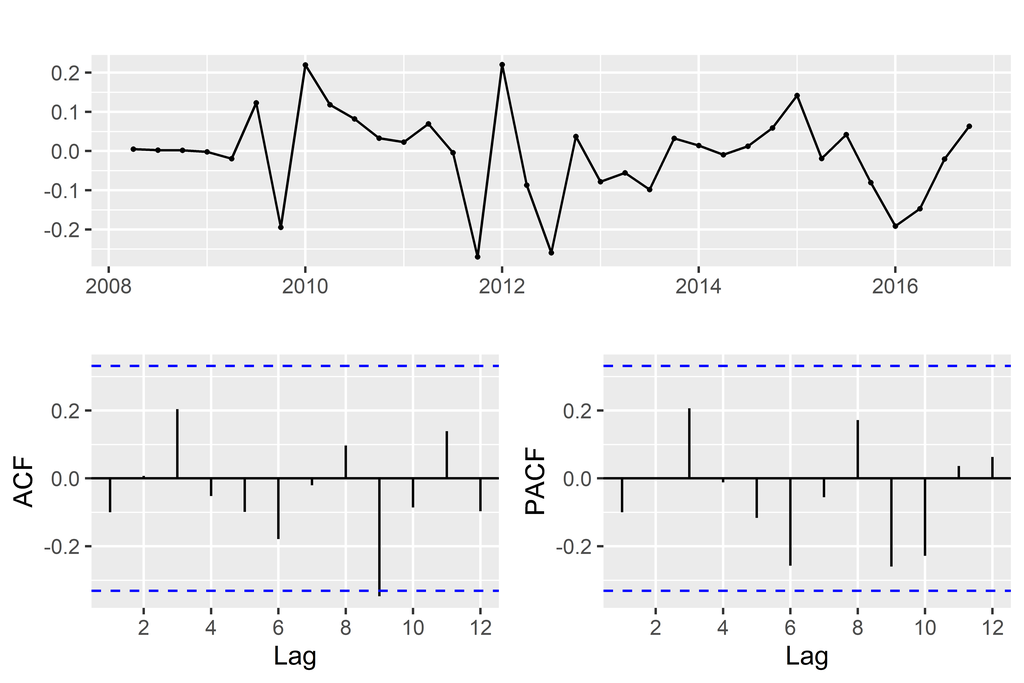

```r
# analizamos si el modelo seleccionado cumple con la condicion de ser ruido blanco
# que ACF y PACF sean cero para todos los retardos
ggtsdisplay(fit2$residuals)
```

### Test Box L-jung

```r
# retardo 4
Box.test(fit2$residuals,lag=4, fitdf=1, type="Lj")
```

```
##
##  Box-Ljung test
##
## data:  fit2$residuals
## X-squared = 2.1794, df = 3, p-value = 0.536
```

```r
# p value igual a 0.536, mayor de 5%. Se acepta la Ho ausencia de correlacion por tanto ruido blanco
```

```r
# retardo 6
Box.test(fit2$residuals,lag=6, fitdf=1, type="Lj")
```

```
##
##  Box-Ljung test
##
## data:  fit2$residuals
## X-squared = 4.0334, df = 5, p-value = 0.5446
```

```r
# p value igual a 0.5446, mayor de 5%. Se acepta la Ho ausencia de correlacion por tanto ruido blanco
```

```r
# retardo 8
Box.test(fit2$residuals,lag=8, fitdf=1, type="Lj")
```

```
##
##  Box-Ljung test
##
## data:  fit2$residuals
## X-squared = 4.501, df = 7, p-value = 0.7206
```

```r
# p value igual a 0.7206, mayor de 5%. Se acepta la Ho ausencia de correlacion por tanto ruido blanco
```

En el gráfico anterior puede observarse que los residuos son ruido blanco ya que tanto la autocorrelación simple (ACF) como la autocorrelación parcial (pafc) son cero para todo los retardos (las lineas estan dentro de las baldas, por tanto, es estadisticamente igual a 0), excepto el 9 del ACF.

Además, el test de Box-Ljung confirma esto pues en todos los casos se ha aceptado la hipótesis nula que confirma la ausencia de correlación.

### Predicción

```r
# prediccion
prventas.arima <- forecast(fit2)
```

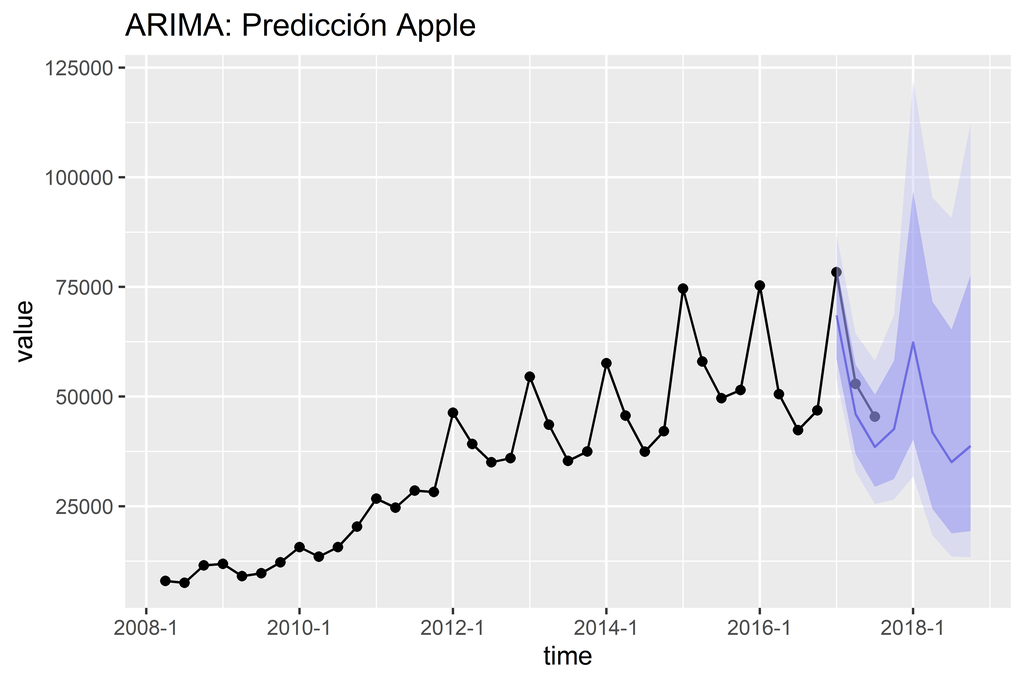

```r
# grafica
# geom_point para los puntos
# geom_line para las lineas de union
# alpha dibuja la transparencia y con forecast la prediccion de ventas
ggplot(df_apple) + geom_point(aes(x=time,y=value)) +
geom_line(aes(x=time,y=value)) + geom_forecast(prventas.arima,alpha=0.4) + ggtitle("ARIMA: Predicción Apple")
```

En esta gráfica quedan proyectados los valores de la serie para el año 2017 y 2018, se puede apreciar con el sombreado de color azul. Posteriormente podemos conocer las cifras exactas con la siguiente tabla. Si las comparamos con las cifras reales de nuestra base de datos vemos que las predicciones son pesimistas y que Apple finalmente obtuvo mayores ingresos de los previstos durante los 3 primeros trimestres de 2017.

```r
# vemos los datos
prventas.arima
```

```
##         Point Forecast    Lo 80    Hi 80    Lo 95     Hi 95
## 2017 Q1       68524.50 58656.57 80052.53 54021.77  86920.63
## 2017 Q2       45993.21 36914.17 57305.26 32857.77  64379.78
## 2017 Q3       38534.34 29436.35 50444.28 25525.07  58174.00
## 2017 Q4       42622.67 31230.74 58169.99 26490.28  68579.55
## 2018 Q1       62338.78 40156.60 96774.23 31816.09 122143.34
## 2018 Q2       41841.40 24416.21 71702.49 18358.80  95360.44
## 2018 Q3       35055.84 18821.04 65294.59 13541.05  90754.54
## 2018 Q4       38775.11 19344.31 77723.59 13387.03 112310.89
```